[← Back to All Parables](https://www.kameronyork.com/parables/)

# The Wise and Foolish Builders

by Kameron York

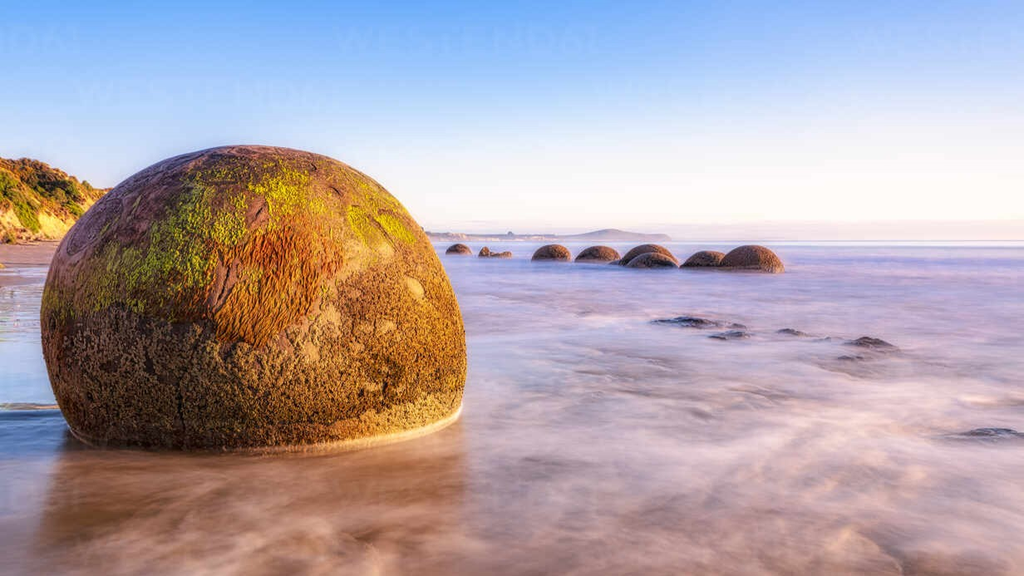

#### Reference: [Matthew 7:24-28](https://www.churchofjesuschrist.org/study/scriptures/nt/matt/7?lang=eng&id=24-28#p24) [Luke 6:46-49](https://www.churchofjesuschrist.org/study/scriptures/nt/luke/6?lang=eng&id=46-49#p46)

### Insights here:

##### General Conference

The General Conference talks (listed below) are of interest for this study.  
**Elder L. Tom Perry** in April 1985 relates a story of laying the foundation for the church’s exhibit at the New York World’s Fair. “…we were using a pile driver because of the lack of a solid foundation. Big wooden piles about the size of those used for telephone poles were being driven into the ground to form the foundation of our pavilion.” Through great effort the soft foundation was transformed into a firm foundation.  
**Elder Adhemar Damiani** in October 1999 noted that both houses, regardless of their foundation type, recieved the weathering of the storm.  
“The rain, the floods, and the winds beat not only upon the house which had been built upon the sand, but also upon the other, which had been built upon the rock.  
Both the person who serves the Lord as well as the one who disdains Him live in a world ruled by the same laws of nature.”  
Life is hard for everyone, this parable does not promise followers of Christ an easier time. Temptation will affect everyone, we will all lose loved ones, and everyone is subject to suffering. However, the main difference between the two builders the the one built on the rock did not fall.  
**Elder Keith W. Wilcox** in April 1985 mentioned how we can build our lives on the rock. He taught that the rock we are to build on is Jesus Christ and His words. Specifically he mentioned the Sermon on the Mount, saying, “As we live the principles of the Sermon on the Mount, we build a rock-solid foundation upon which our lives can safely be constructed. The Lord, the great Master Architect, has given us perfect plans and specifications to guide us in the building of our lives. These are the sacred scriptures. They contain the words of the Lord and should be frequently read and pondered.”

##### Other Insights

“…did not fall.” This does not mean the roof didn’t leak, that there wasn’t a bit of flooding, or that the family inside wasn’t afraid of the storm. We aren’t impervious to pain and imperfections, but we are promised we will not *fall*.

##### Differences between Matthew and Luke

1. **Coming to Christ**: Matthew records Jesus as saying, “…whosoever heareth these sayings of mine, and doeth them…” while Luke records, “Whosoever **cometh to me**, and heareth my sayings, and doeth them…”. Luke mentions the importance of following Christ along with hearing His words.
2. **Digging to the Foundation**: Luke records the wise man digging through the sand to find the firm foundation to build his house on. Matthew only mentions the stone, not how it was found. This is an important reminder that building our lives on the foundation of Christ takes work to find it.
3. **Without a Foundation**: Luke teaches specifically that the foolish man built hos house on sand **without a foundation**. That’s a small difference as it can be inferred in Matthew’s account, but this re-emphasizes the importance of finding and building on a solid foundation.

[output not shown]